# #Exploratory data Analysis to determine the quality of red wine by VINAYAK NAYAK

```
## [1] "C:/Users/vnayak/Documents/github_R"
```

```
##  [1] "X"                    "fixed.acidity"        "volatile.acidity"
##  [4] "citric.acid"          "residual.sugar"       "chlorides"
##  [7] "free.sulfur.dioxide"  "total.sulfur.dioxide" "density"
## [10] "pH"                   "sulphates"            "alcohol"
## [13] "quality"
```

```
## 'data.frame':    1599 obs. of  13 variables:
##  $ X                   : int  1 2 3 4 5 6 7 8 9 10 ...
##  $ fixed.acidity       : num  7.4 7.8 7.8 11.2 7.4 7.4 7.9 7.3 7.8 7.5 ...
##  $ volatile.acidity    : num  0.7 0.88 0.76 0.28 0.7 0.66 0.6 0.65 0.58 0.5 ...
##  $ citric.acid         : num  0 0 0.04 0.56 0 0 0.06 0 0.02 0.36 ...
##  $ residual.sugar      : num  1.9 2.6 2.3 1.9 1.9 1.8 1.6 1.2 2 6.1 ...
##  $ chlorides           : num  0.076 0.098 0.092 0.075 0.076 0.075 0.069 0.065 0.073 0.071 ...
##  $ free.sulfur.dioxide : num  11 25 15 17 11 13 15 15 9 17 ...
##  $ total.sulfur.dioxide: num  34 67 54 60 34 40 59 21 18 102 ...
##  $ density             : num  0.998 0.997 0.997 0.998 0.998 ...
##  $ pH                  : num  3.51 3.2 3.26 3.16 3.51 3.51 3.3 3.39 3.36 3.35 ...
##  $ sulphates           : num  0.56 0.68 0.65 0.58 0.56 0.56 0.46 0.47 0.57 0.8 ...
##  $ alcohol             : num  9.4 9.8 9.8 9.8 9.4 9.4 9.4 10 9.5 10.5 ...
##  $ quality             : int  5 5 5 6 5 5 5 7 7 5 ...
```

```
##        X          fixed.acidity   volatile.acidity  citric.acid
##  Min.   :   1.0   Min.   : 4.60   Min.   :0.1200   Min.   :0.000
##  1st Qu.: 400.5   1st Qu.: 7.10   1st Qu.:0.3900   1st Qu.:0.090
##  Median : 800.0   Median : 7.90   Median :0.5200   Median :0.260
##  Mean   : 800.0   Mean   : 8.32   Mean   :0.5278   Mean   :0.271
##  3rd Qu.:1199.5   3rd Qu.: 9.20   3rd Qu.:0.6400   3rd Qu.:0.420
##  Max.   :1599.0   Max.   :15.90   Max.   :1.5800   Max.   :1.000
##  residual.sugar     chlorides       free.sulfur.dioxide
##  Min.   : 0.900   Min.   :0.01200   Min.   : 1.00
##  1st Qu.: 1.900   1st Qu.:0.07000   1st Qu.: 7.00
##  Median : 2.200   Median :0.07900   Median :14.00
##  Mean   : 2.539   Mean   :0.08747   Mean   :15.87
##  3rd Qu.: 2.600   3rd Qu.:0.09000   3rd Qu.:21.00
##  Max.   :15.500   Max.   :0.61100   Max.   :72.00
##  total.sulfur.dioxide    density             pH          sulphates
##  Min.   :  6.00       Min.   :0.9901   Min.   :2.740   Min.   :0.3300
##  1st Qu.: 22.00       1st Qu.:0.9956   1st Qu.:3.210   1st Qu.:0.5500
##  Median : 38.00       Median :0.9968   Median :3.310   Median :0.6200
##  Mean   : 46.47       Mean   :0.9967   Mean   :3.311   Mean   :0.6581
##  3rd Qu.: 62.00       3rd Qu.:0.9978   3rd Qu.:3.400   3rd Qu.:0.7300
##  Max.   :289.00       Max.   :1.0037   Max.   :4.010   Max.   :2.0000
##     alcohol         quality
##  Min.   : 8.40   Min.   :3.000
##  1st Qu.: 9.50   1st Qu.:5.000
##  Median :10.20   Median :6.000
##  Mean   :10.42   Mean   :5.636
##  3rd Qu.:11.10   3rd Qu.:6.000
##  Max.   :14.90   Max.   :8.000
```

Our data set contains 1599 observations of 13 variables.

# Univariate Plots Section

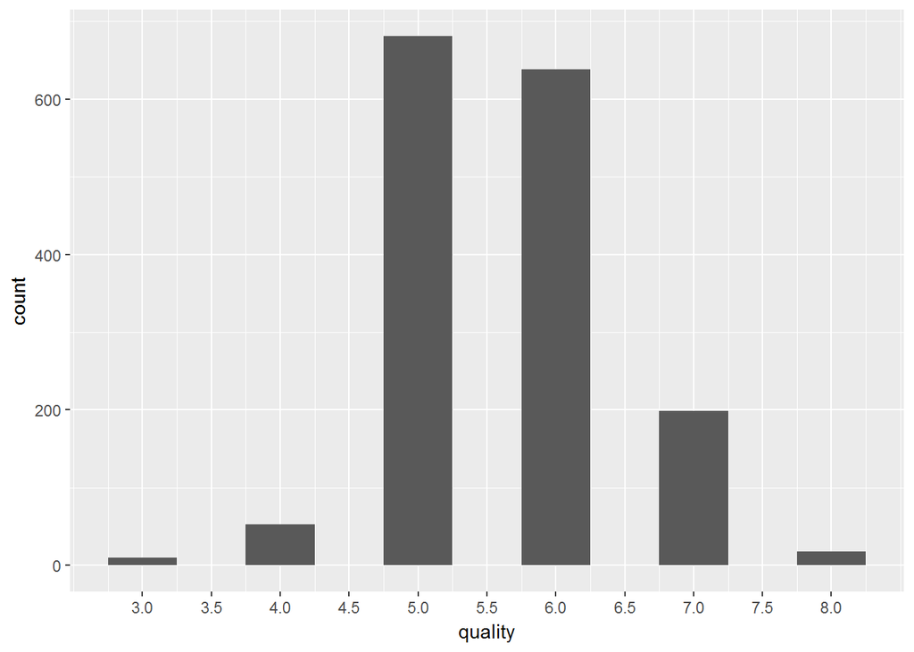

```
##    Min. 1st Qu.  Median    Mean 3rd Qu.    Max.
##    8.40    9.50   10.20   10.42   11.10   14.90
```

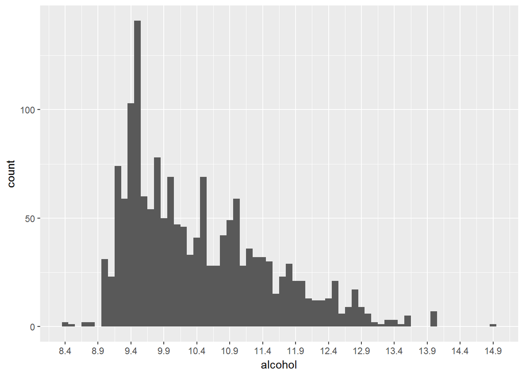

In the above graph we see that the data is skewed to the right. So we will apply log transformation to the x axis. We see bi modal distribution in our graph.

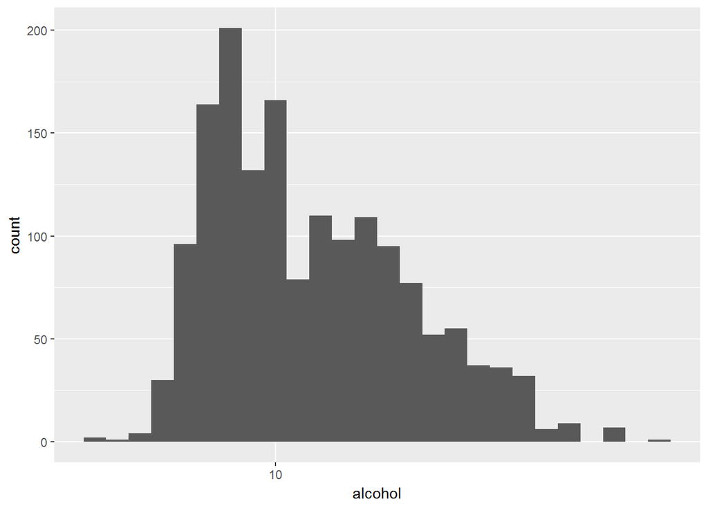

[figure not shown]

```
##    Min. 1st Qu.  Median    Mean 3rd Qu.    Max.
##  0.3300  0.5500  0.6200  0.6581  0.7300  2.0000
```

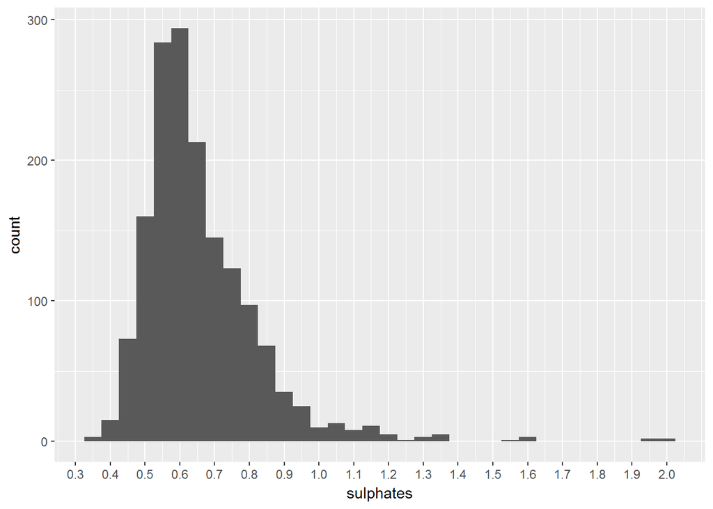

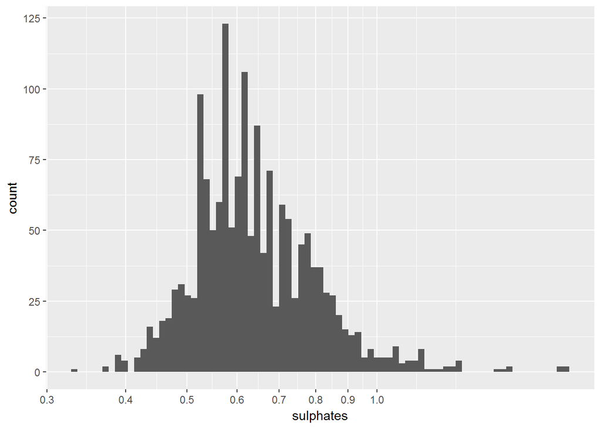

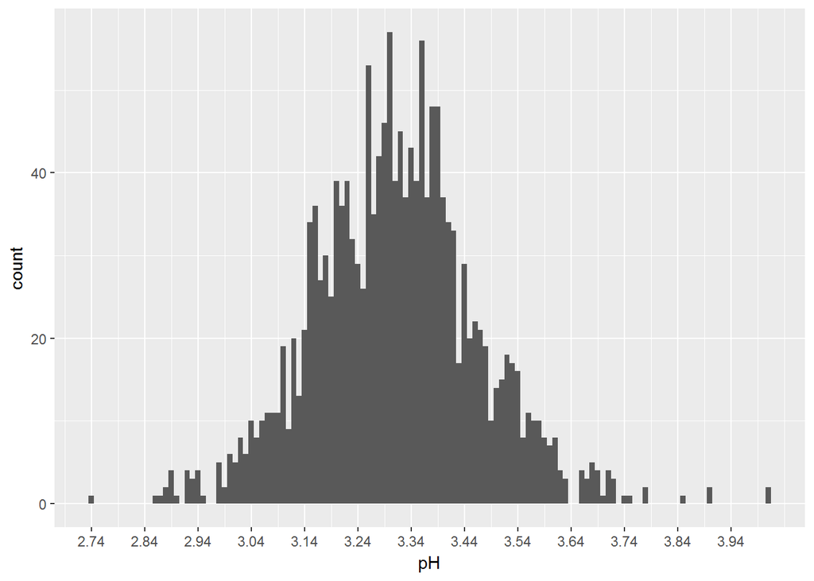

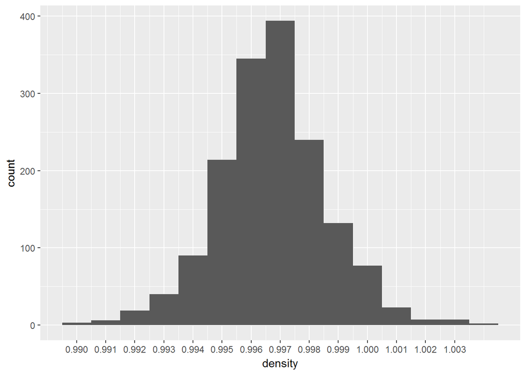

```
##    Min. 1st Qu.  Median    Mean 3rd Qu.    Max.
##   0.900   1.900   2.200   2.539   2.600  15.500
```

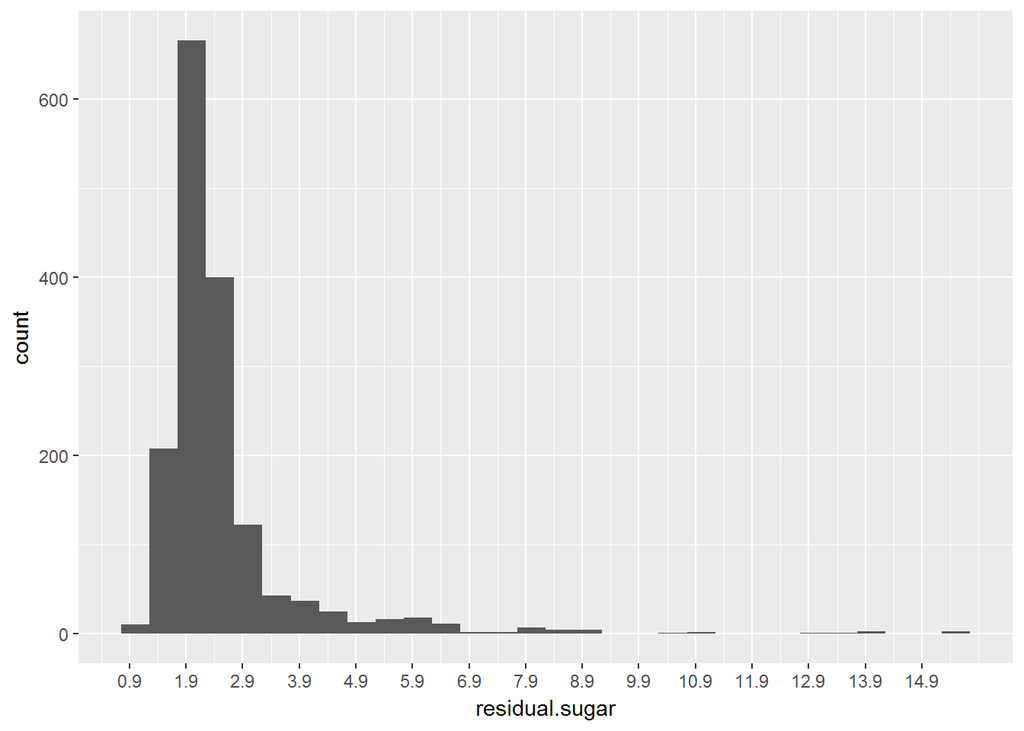

The graph above shows it is skewed to right. We will apply log transformation.

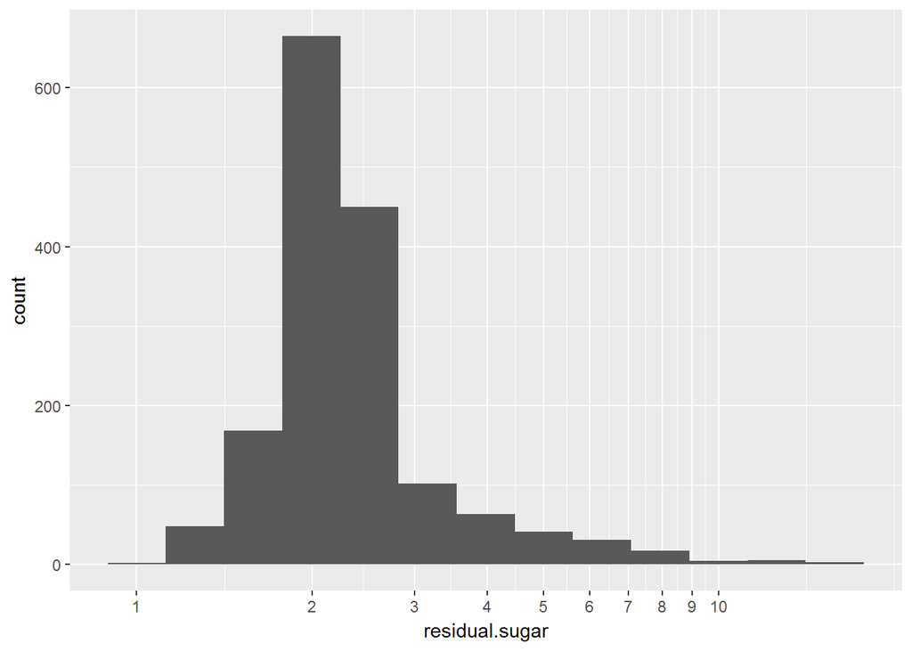

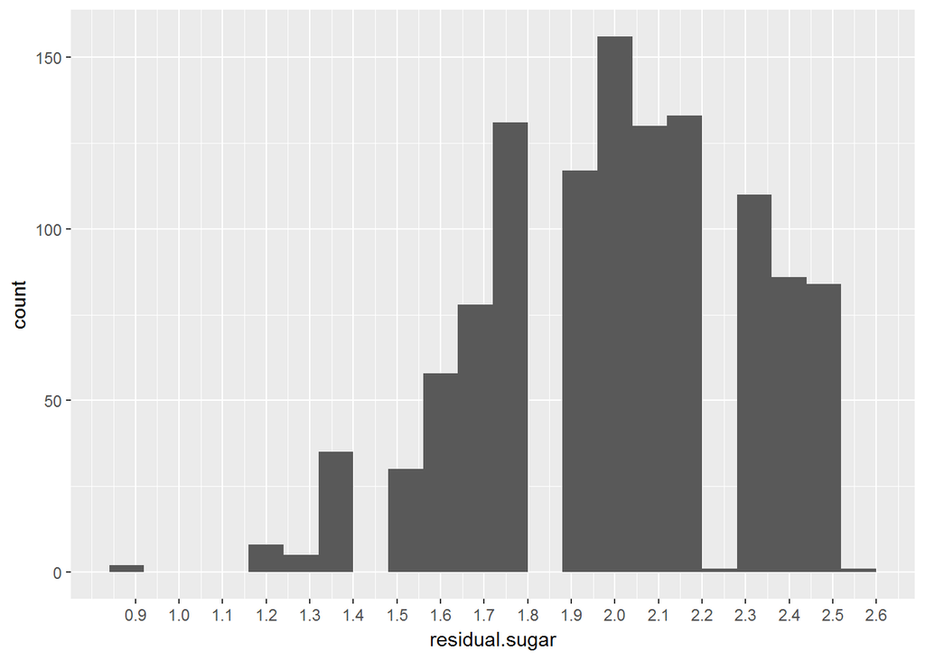

I will create a new variable called quality.factor which will be helpful in plotting box plots . Since quality it is a continous variable we will make the new variable as factor var.

# Univariate Analysis

Structure of the dataset. There are 1599 observation with 13 variables (x,fixed.acidity,volatile.acidity,citric.acid,residual.sugar,chlorides,free.sulphur.dioxide,density,pH,sulphates,alcohol,quality).X and quality are int variable and rest of the variables are num.

### Other observations:

quality has minimum value of 3. Median is 6. Mean is 5.635, MAx is 8. The count of density is more with density value from 0.996 to 0.997 residual sugar has median value as 2.200,mean is 2.539. But the max value is 15.500 which seems to be an outlier in the data. fixed.acidity has median value as 7.90,mean as 8.32, but the max value os 15.90 which is an outlier.

### Main feature(s) of interest in dataset

The main feature of interest in your dataset is to observe the quality of the red wine.Also how other factors like alcohol,pH,residual sugar affect the quality of the red wine.

### Other features in the dataset I think will help support my investigation into the feature(s) of interest?

Fixed.acidity,volatile.acidity and citric.acid are other features that may help in investigation

### Create any new variables from existing variables in the dataset

New variable created is :: redwinedf$quality.factor

# Bivariate Plots Section

```
##
##  Pearson's product-moment correlation
##
## data:  redwinedf$quality and redwinedf$alcohol
## t = 21.639, df = 1597, p-value < 2.2e-16
## alternative hypothesis: true correlation is not equal to 0
## 95 percent confidence interval:
##  0.4373540 0.5132081
## sample estimates:
##       cor
## 0.4761663
```

```
##
##  Pearson's product-moment correlation
##
## data:  redwinedf$quality and redwinedf$pH
## t = -2.3109, df = 1597, p-value = 0.02096
## alternative hypothesis: true correlation is not equal to 0
## 95 percent confidence interval:
##  -0.106451268 -0.008734972
## sample estimates:
##         cor
## -0.05773139
```

```
##
##  Pearson's product-moment correlation
##
## data:  redwinedf$quality and redwinedf$residual.sugar
## t = 0.5488, df = 1597, p-value = 0.5832
## alternative hypothesis: true correlation is not equal to 0
## 95 percent confidence interval:
##  -0.03531327  0.06271056
## sample estimates:
##        cor
## 0.01373164
```

```
##
##  Pearson's product-moment correlation
##
## data:  redwinedf$quality and redwinedf$fixed.acidity
## t = 4.996, df = 1597, p-value = 6.496e-07
## alternative hypothesis: true correlation is not equal to 0
## 95 percent confidence interval:
##  0.07548957 0.17202667
## sample estimates:
##       cor
## 0.1240516
```

```
##
##  Pearson's product-moment correlation
##
## data:  redwinedf$quality and redwinedf$volatile.acidity
## t = -16.954, df = 1597, p-value < 2.2e-16
## alternative hypothesis: true correlation is not equal to 0
## 95 percent confidence interval:
##  -0.4313210 -0.3482032
## sample estimates:
##        cor
## -0.3905578
```

```
##
##  Pearson's product-moment correlation
##
## data:  redwinedf$quality and redwinedf$citric.acid
## t = 9.2875, df = 1597, p-value < 2.2e-16
## alternative hypothesis: true correlation is not equal to 0
## 95 percent confidence interval:
##  0.1793415 0.2723711
## sample estimates:
##       cor
## 0.2263725
```

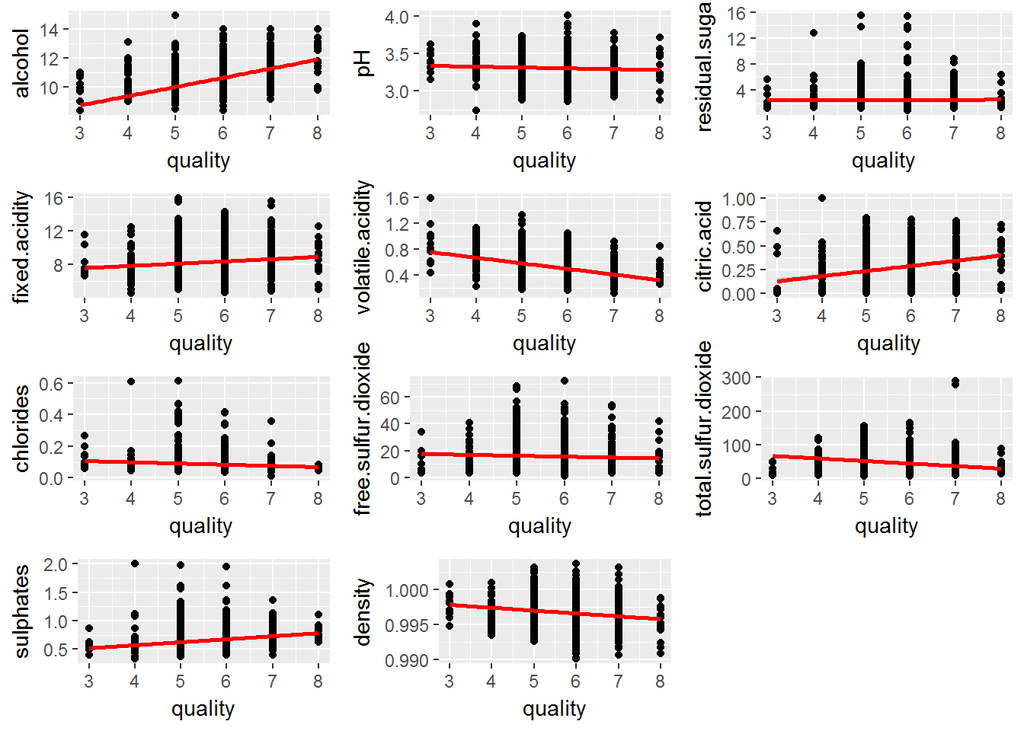

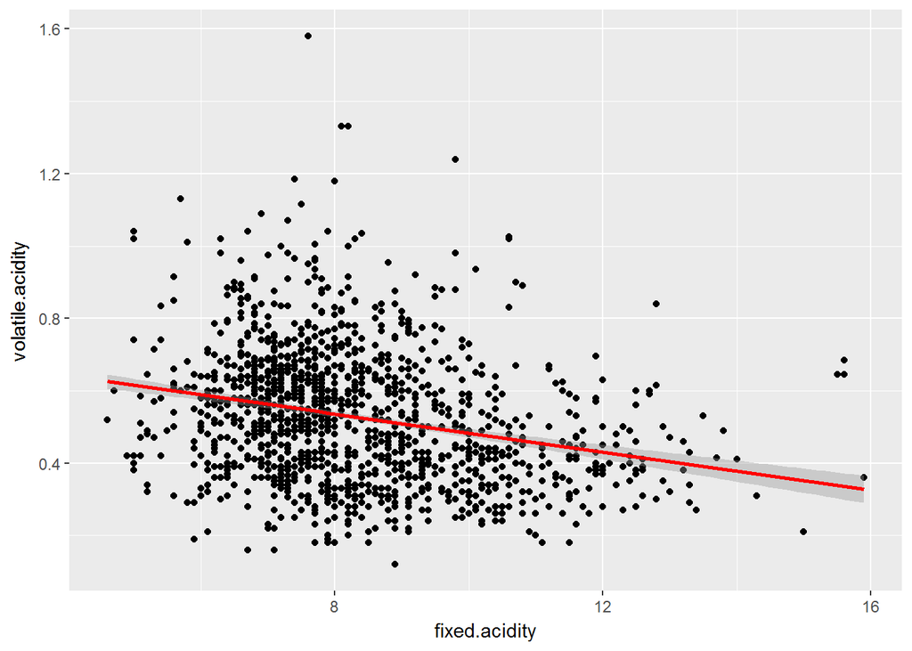

```
##
##  Pearson's product-moment correlation
##
## data:  redwinedf$fixed.acidity and redwinedf$volatile.acidity
## t = -10.589, df = 1597, p-value < 2.2e-16
## alternative hypothesis: true correlation is not equal to 0
## 95 percent confidence interval:
##  -0.3013681 -0.2097433
## sample estimates:
##        cor
## -0.2561309
```

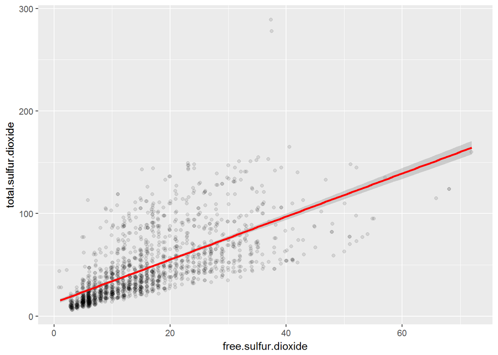

```
##
##  Pearson's product-moment correlation
##
## data:  redwinedf$free.sulfur.dioxide and redwinedf$total.sulfur.dioxide
## t = 35.84, df = 1597, p-value < 2.2e-16
## alternative hypothesis: true correlation is not equal to 0
## 95 percent confidence interval:
##  0.6395786 0.6939740
## sample estimates:
##       cor
## 0.6676665
```

We see that there is strong relationship between free.sulphur.dioxide and #total.sulphur.dioxide.

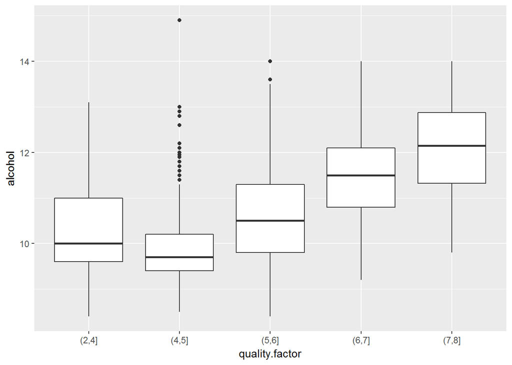

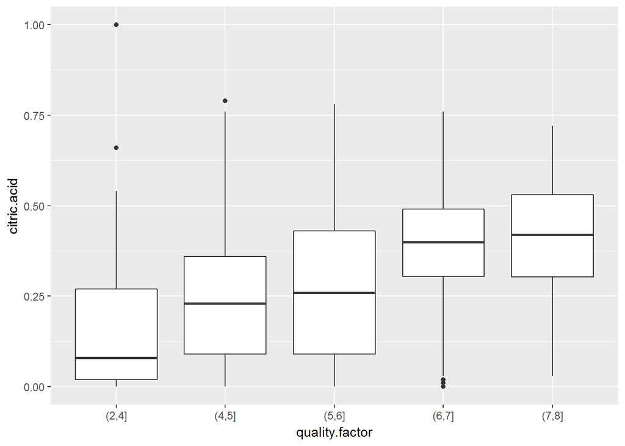

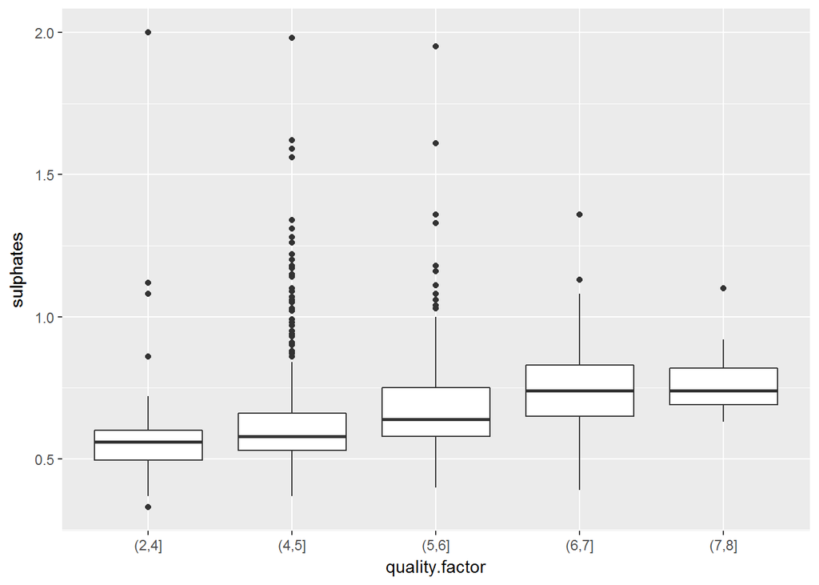

# Bivariate Analysis

### Interesting relationships between the other features (not the main feature(s) of interest)?

We see that there is strong relationship between free.sulphur.dioxide and total.sulphur.dioxide.

### Strongest relationship.

Strongest correlation between free.sulfur.dioxide and total.sulfur.dioxide. Second co relation is beween alcohol and quality.

# Multivariate Plots Section

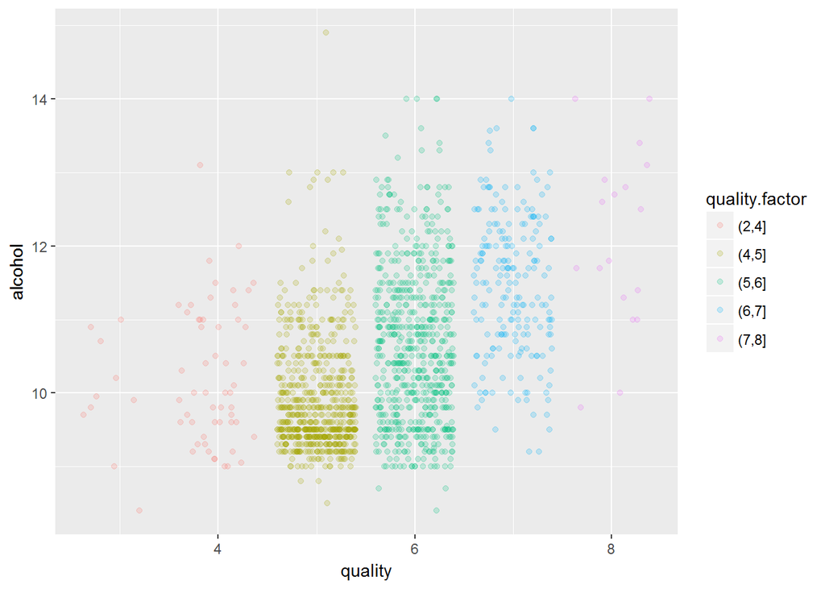

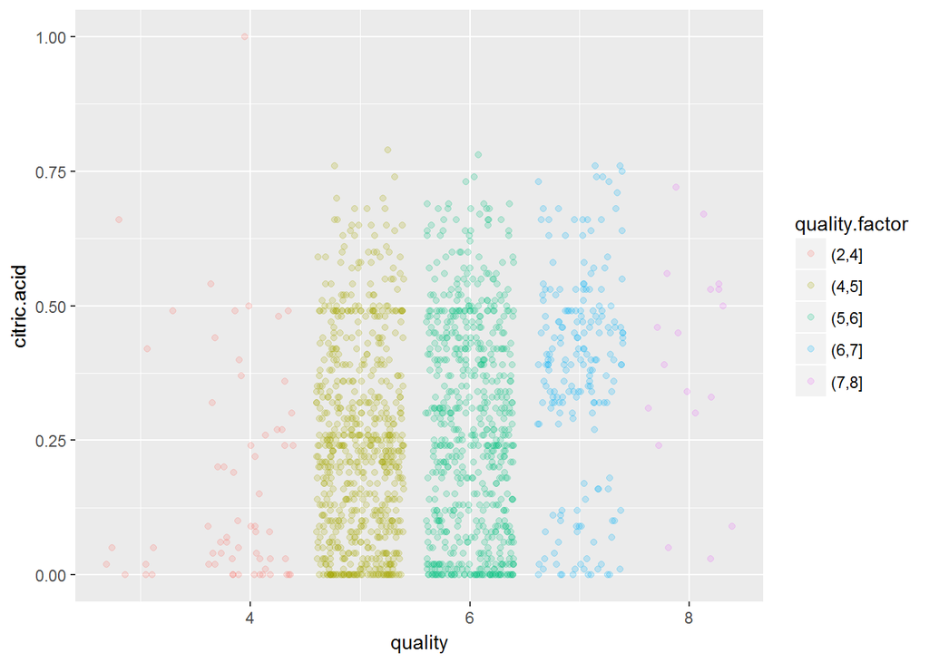

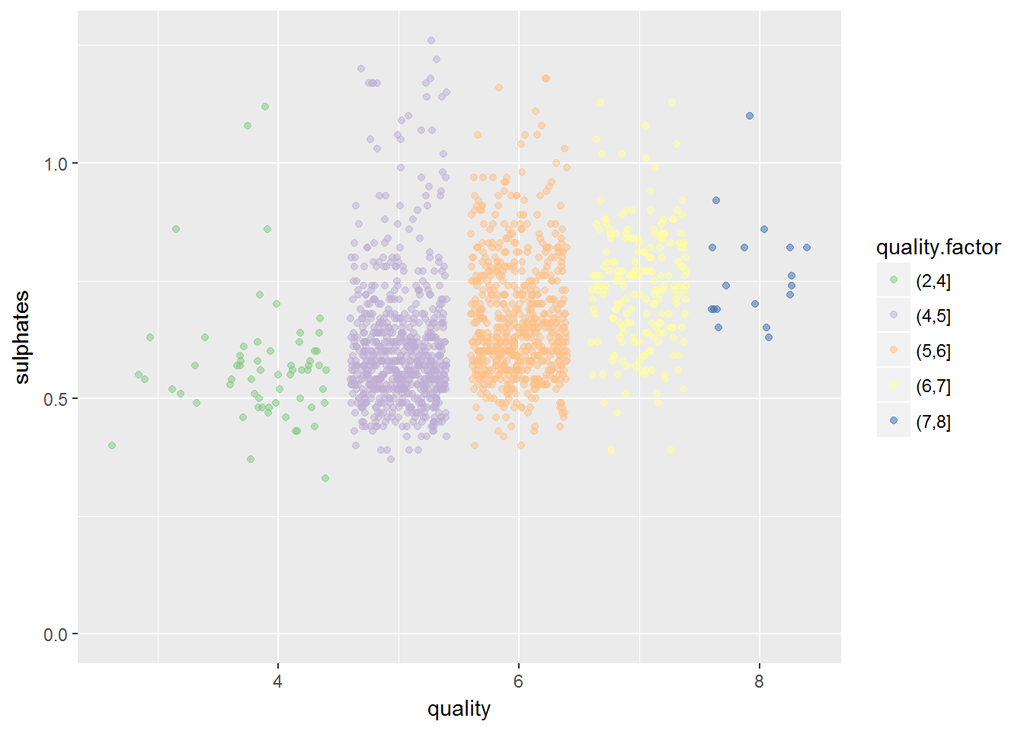

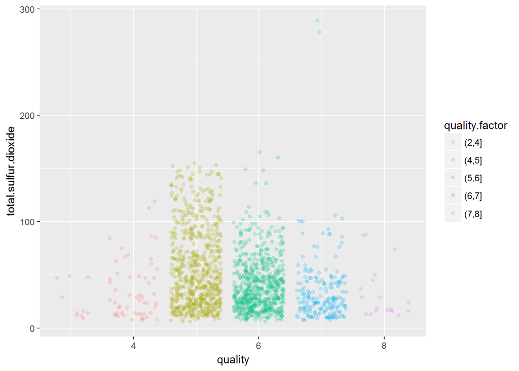

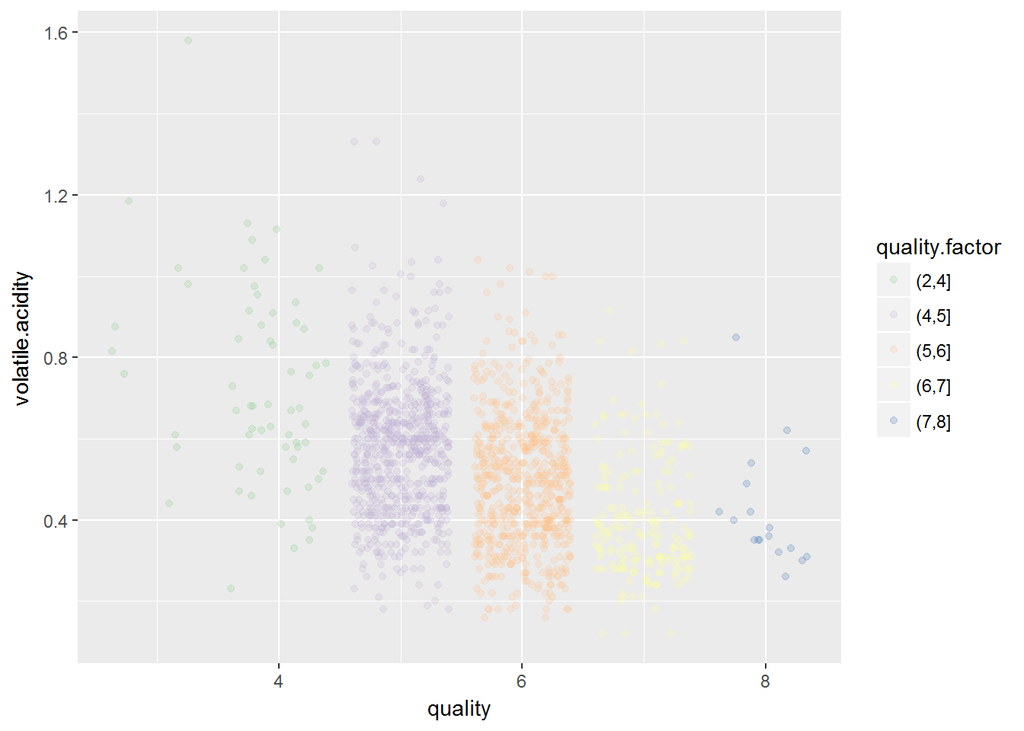

From the above observation we see that quality of the alcohol increases with the decrease in volatile.acidity.So there is non linear relationship.

# Multivariate Analysis

### Relationship between the variables.

### Relationship between quality and alcohol shows strong relationship between the two variables.

# Final Plots and Summary

### Plot One

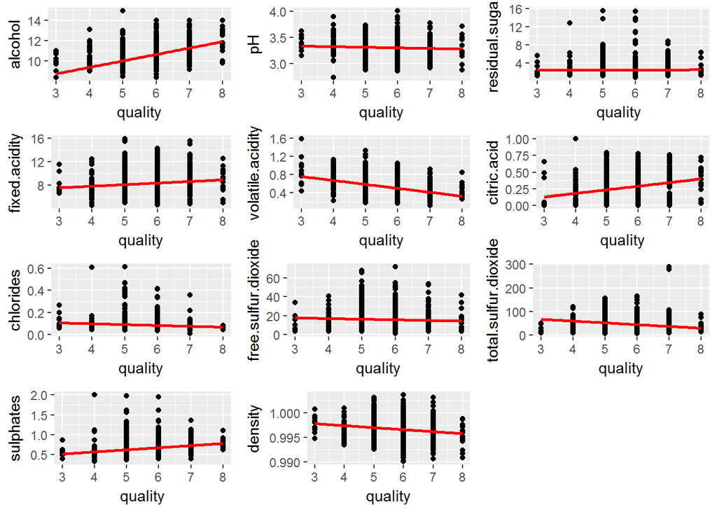

### Description One

This graph shows the relationship between quality and all the other variables. It also displays whether the relationship between the two variables are linear, non-linear or there is no strong relationship between the variables.

### Plot Two

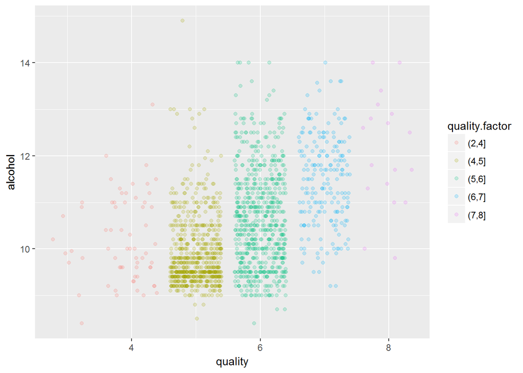

### Description Two

We observe strong relationship between alcohol and quality variable in the redwine dataset.

# Reflection

In our Final plots and Summary section all the variables can be observed in the graph. After exploring the dataset I observed that the data poins are distributed equally due to which we cannot make a significant decision about the dataset. More data may be required to find a strong pattern in data. Then we can create a predictive model to determine the quality of the alcohol based on various inputs.